# HW5

Author

Keara Kirberger

# The Office

Let’s return to *The Office* and the question of how many times they said “that’s what she said”. Now we can use n-grams to help us with the searching. Recall that the text is in the [schrute](https://cran.r-project.org/web/packages/schrute/index.html) package on CRAN.

Do the following: (please label each section with the same number as listed here)

1. Count the number of lines in which “that’s what she said” is said in *The Office* (yes, we discussed this previously)
2. Confirm that you get the same result when using `ngram4`, a variable which is an ngram of size 4 (4 words at a time).
3. Explore whether “that’s what she” included in `ngram4` allows you to determine any additional phrases that should be included.
4. Explore whether “what she said” included in `ngram4` allows you to determine any additional phrases that should be included.
5. Print all the unique lines that contain the words “that”, “what”, “she” and “said”, but do NOT contain the string “that’s what she said”. Decide whether any of these lines should be included as saying “that’s what she said”.
6. Create a frequency distribution of X, where X is determined from the third word in “that’s what X said”.
7. Add a categorical variable to the *original* data that takes a value that equals 0 if it was not identified in your work above, 1 if the line says “that’s what she said”, otherwise it should say 3 if you identified it from starting with “that’s what she”, otherwise it should say 4 if you identified it from ending with “what she said”, otherwise if should say 5 if you identified it in part 5, otherwise it should say 6 if you identified it in part 6. In part 6, you are welcome to make a judgment call about which third words you want to count as similar to “that’s what she said” (but you should clearly state which ones you have chosen).
8. Create a frequency distribution of the new variable you created in part 7.

# setup

```r
library(schrute)
library(tidyverse)
library(tidytext)
```

# part 1

```r
theoffice |>
  mutate(text_lower = str_to_lower(text)) |>
  summarise(total = sum(str_count(text_lower, "that's what she said")))
```

```
# A tibble: 1 × 1
  total
  <int>
1    35
```

# part 2

```r
theoffice |>
  mutate(text_lower = str_to_lower(text)) |>
  unnest_tokens(ngram4, text_lower, "ngrams", n=4) |>
  filter(ngram4 == "that's what she said") |>
  nrow()
```

```
[1] 35
```

# part 3

```r
theoffice |>
  mutate(text_lower = str_to_lower(text)) |>
  unnest_tokens(ngram4, text_lower, "ngrams", n=4) |>
  filter(str_detect(ngram4, "that's what she ") == TRUE) |>
  distinct(ngram4, .keep_all = TRUE) |>
  select(ngram4, text)
```

```
# A tibble: 4 × 2
  ngram4                text
  <chr>                 <chr>
1 that's what she said  That's what she said. Pam?
2 that's what she sai   That's what she sai Nope, but... Okay. Well, suit yours…
3 that's what she a     That's what she... a lot of places are like that.
4 that's what she would People turn to their families all the time when they ne…
```

The second and third phrases should be included.

# part 4

```r
theoffice |>
  mutate(text_lower = str_to_lower(text)) |>
  unnest_tokens(ngram4, text_lower, "ngrams", n=4) |>
  filter(str_detect(ngram4, " what she said") == TRUE) |>
  distinct(ngram4, .keep_all = TRUE) |>
  select(ngram4, text)
```

```
# A tibble: 1 × 2
  ngram4               text
  <chr>                <chr>
1 that's what she said That's what she said. Pam?
```

There are no additional phrases that should be included here.

# part 5

```r
theoffice |>
  mutate(text_lower = str_to_lower(text)) |>
  filter(str_detect(text_lower, "that's") == TRUE,
         str_detect(text_lower, "what") == TRUE,
         str_detect(text_lower, "she") == TRUE,
         str_detect(text_lower, "said") == TRUE,
         str_detect(text_lower, "that's what she said") == FALSE) |>
  distinct(text_lower, .keep_all = TRUE) |>
  select(text)
```

```
# A tibble: 2 × 1
  text
  <chr>
1 "Is it a priority? Oh I don't know, um, what if there is a tornado, Pam? Peop…
2 "Pam can't drink? I didn't-- I shouldn't have said that. I don't know why I d…
```

These lines should not be included.

# part 6

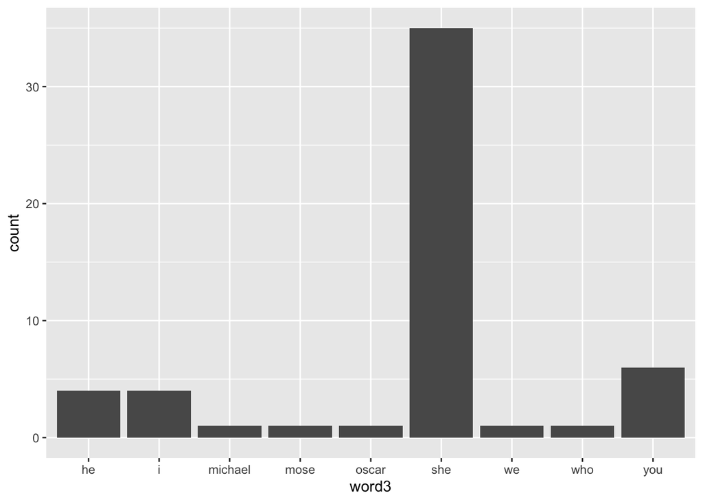

```r
theoffice |>
  mutate(text_lower = str_to_lower(text)) |>
  unnest_tokens(ngram4, text_lower, "ngrams", n=4) |>
  separate(ngram4, into = c("word1", "word2", "word3", "word4"), sep = " ") |>
  filter(word1 == "that's",
         word2 == "what",
         word4 == "said") |>
  ggplot(aes(x = word3)) +
  geom_bar()
```

# part 7

From part 6, I decided to include “that’s what he said.”

```r
theoffice <- theoffice |>
  mutate(text_lower = str_to_lower(text)) |>
  unnest_tokens(ngram4, text_lower, "ngrams", n=4) |>
  mutate(twss = case_when(
    ngram4 == "that's what she said" ~ 1,
    ngram4 == c("that's what she a", "that's what she sai") ~ 3,
    ngram4 == c("that's what he said") ~ 6,
    TRUE ~ 0
  ))
```

# part 8

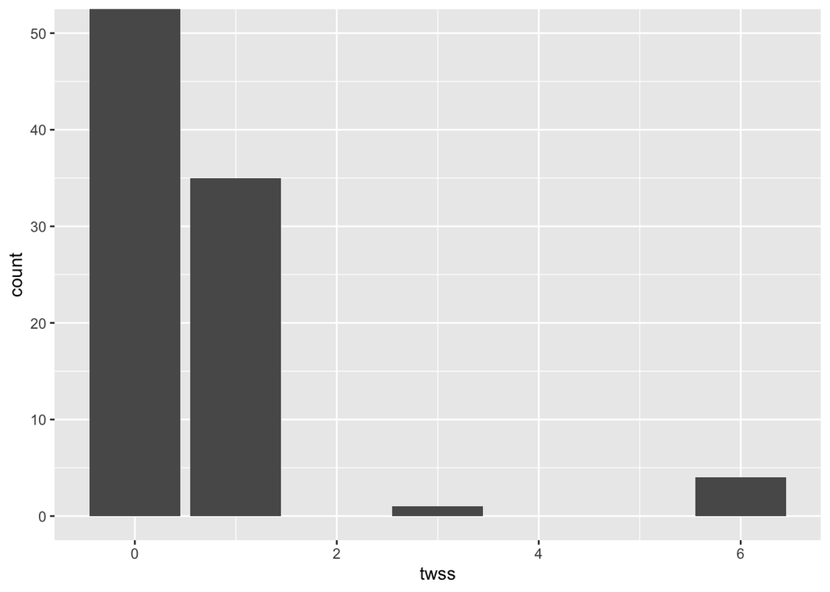

```r
theoffice |>
  ggplot(aes(x = twss)) +
  geom_bar() +
  coord_cartesian(ylim = c(0, 50))
```

Since the count for 0 is so much larger than the others, I limited the y-axis at 50 so the other bars could be seen on the graph.